# Fast big-memory workflows with bigPLScox

Frédéric Bertrand

Cedric, Cnam, Paris  
frederic.bertrand@lecnam.net

2025-11-17

# Introduction

Large survival datasets often outgrow the capabilities of purely in-memory algorithms. **bigPLScox** therefore offers three flavours of Partial Least Squares (PLS) components for Cox models:

1. `big_pls_cox()` – the original R/C++ hybrid that expects dense matrices;
2. `big_pls_cox_fast()` – the new Armadillo backend with variance-one components and support for both dense matrices and `bigmemory::big.matrix` objects; and
3. `big_pls_cox_gd()` – a stochastic gradient descent (SGD) solver for streaming or disk-backed data. allowing datasets too large to fit in RAM.

This vignette demonstrates how to build file-backed matrices, run the fast backends, and reconcile their outputs. It complements the introductory vignette `vignette("getting-started", package = "bigPLScox")` and focuses on workflow patterns specific to large datasets.

# Simulating a large survival dataset

We generate a synthetic dataset with correlated predictors and a known linear predictor. The same object is used to illustrate the dense and big-memory interfaces.

```r
library(bigPLScox)
set.seed(2024)

n_obs  <- 5000
n_pred <- 100
k_true <- 3

Sigma <- diag(n_pred)
for (b in 0:2) {
  idx <- (b * 10 + 1):(b * 10 + 10)
  Sigma[idx, idx] <- 0.7
  diag(Sigma[idx, idx]) <- 1
}

L <- chol(Sigma)
Z <- matrix(rnorm(n_obs * n_pred), nrow = n_obs)
X_dense <- Z %*% L

w1 <- numeric(n_pred); w1[1:4]   <- c( 1.0,  0.8,  0.6, -0.5)
w2 <- numeric(n_pred); w2[5:8]   <- c(-0.7,  0.9, -0.4,  0.5)
w3 <- numeric(n_pred); w3[9:12]  <- c( 0.6, -0.5,  0.7,  0.8)
w1 <- w1 / sqrt(sum(w1^2))
w2 <- w2 / sqrt(sum(w2^2))
w3 <- w3 / sqrt(sum(w3^2))

t1 <- as.numeric(scale(drop(X_dense %*% w1), center = TRUE, scale = TRUE))
t2 <- as.numeric(scale(drop(X_dense %*% w2), center = TRUE, scale = TRUE))
t3 <- as.numeric(scale(drop(X_dense %*% w3), center = TRUE, scale = TRUE))

beta_true <- c(1.0, 0.6, 0.3)
eta       <- beta_true[1]*t1 + beta_true[2]*t2 + beta_true[3]*t3

lambda0 <- 0.05
u <- runif(n_obs)
time_event <- -log(u) / (lambda0 * exp(eta))

target_event <- 0.65

f <- function(lc) {
  mean(time_event <= rexp(n_obs, rate = lc)) - target_event
}
lambda_c <- uniroot(f, c(1e-4, 1), tol = 1e-4)$root
time_cens <- rexp(n_obs, rate = lambda_c)

time   <- pmin(time_event, time_cens)
status <- as.integer(time_event <= time_cens)
```

```r
if (requireNamespace("bigmemory", quietly = TRUE)) {
  library(bigmemory)
  big_dir <- tempfile("bigPLScox-")
  dir.create(big_dir)
  if(file.exists(paste(big_dir,"X.bin",sep="/"))){unlink(paste(big_dir,"X.bin",sep="/"))}
  if(file.exists(paste(big_dir,"X.desc",sep="/"))){unlink(paste(big_dir,"X.desc",sep="/"))}
  X_big <- bigmemory::as.big.matrix(
    X_dense,
    backingpath = big_dir,
    backingfile = "X.bin",
    descriptorfile = "X.desc"
  )
  X_big[1:6, 1:6]
}
```

```
#>            [,1]       [,2]       [,3]       [,4]       [,5]       [,6]
#> [1,]  0.9819694  1.1785102  0.8893563  0.4103456  0.8595229  1.2643346
#> [2,]  0.4687150  0.3552132  0.1072107  0.7865815  0.6736797  0.9825877
#> [3,] -0.1079713 -0.9804778 -1.7053786 -0.3227459 -0.6558693  0.4394022
#> [4,] -0.2128782  0.1114703 -0.8085431 -0.7675984 -0.3685458 -0.7628635
#> [5,]  1.1580985  1.0561296  1.1652026  1.5047814  0.3721924  1.1937471
#> [6,]  1.2923548  1.2431242  1.1954762  1.7104007  1.7505597  0.3548417
```

# Dense-matrix solvers

The legacy solver `big_pls_cox()` performs the component extraction in R before fitting the Cox model. The new `big_pls_cox_fast()` backend exposes the same arguments but runs entirely in C++ for a substantial speed-up.

```r
fit_legacy <- big_pls_cox(
  X = X_dense,
  time = time,
  status = status,
  ncomp = k_true
)
fit_fast_dense <- big_pls_cox_fast(
  X = X_dense,
  time = time,
  status = status,
  ncomp = k_true
)

list(
  legacy = head(fit_legacy$scores),
  fast = head(fit_fast_dense$scores)
)
```

```
#> $legacy
#>            [,1]         [,2]       [,3]
#> [1,]  0.9629914 -0.167053846  0.7375230
#> [2,]  0.2108181 -0.770048070 -0.7462166
#> [3,] -0.6636008  0.469979735 -0.5996875
#> [4,] -0.4659735  0.004452889 -0.5171283
#> [5,]  1.1370381 -1.060165048  0.4919368
#> [6,]  1.1498123  0.643174881 -2.0723580
#>
#> $fast
#>            [,1]        [,2]        [,3]
#> [1,]  0.9687369  0.08567234  0.55026138
#> [2,]  0.2084113 -0.27560071 -0.81298189
#> [3,] -0.6452360  0.17006440 -0.59713551
#> [4,] -0.3704446 -1.74944701 -0.56995206
#> [5,]  1.1710374 -0.97228981 -0.09285005
#> [6,]  1.1309082  1.29090796 -1.67416198
```

```r
list(
  legacy = apply(fit_legacy$scores, 2, var),
  fast = apply(fit_fast_dense$scores, 2, var)
)
```

```
#> $legacy
#> [1] 1 1 1
#>
#> $fast
#> [1] 1 1 1
```

The `summary()` method reports key diagnostics, including the final Cox coefficients and the number of predictors retained per component.

```r
summary(fit_fast_dense)
```

```
#> $n
#> [1] 5000
#>
#> $p
#> [1] 100
#>
#> $ncomp
#> [1] 3
#>
#> $keepX
#> [1] 0 0 0
#>
#> $center
#>   [1]  2.798955e-03 -9.107153e-03 -2.635946e-03 -4.943362e-03 -7.487132e-03
#>   [6]  1.688500e-03  1.210463e-02 -3.535210e-03  7.937559e-03 -5.111552e-03
#>  [11]  2.432002e-02  2.761799e-02  1.006852e-02  1.894906e-02  5.913826e-03
#>  [16]  1.760013e-02  2.038917e-02  1.990905e-02  8.037810e-03  1.348481e-02
#>  [21] -8.386266e-04 -1.395535e-02  1.267194e-03  4.733988e-03 -3.000423e-03
#>  [26]  4.522036e-03  1.537932e-02  7.581824e-03  1.149183e-02  8.462248e-05
#>  [31]  5.932423e-03 -1.466198e-02 -1.034713e-02 -1.481074e-02 -2.251482e-02
#>  [36]  1.509019e-02  7.071338e-03  1.671894e-03 -5.115363e-04  7.012307e-03
#>  [41]  1.064288e-02  9.916201e-03 -6.026108e-03  5.773966e-03  4.633769e-03
#>  [46]  2.618328e-02 -1.435784e-02 -5.742304e-03 -1.915827e-02  8.912658e-03
#>  [51]  9.885805e-04 -2.480366e-02 -2.473665e-02  1.140294e-02 -1.765096e-03
#>  [56]  1.098523e-02  1.313620e-02  1.197506e-02  1.582672e-02 -1.068739e-02
#>  [61]  2.012116e-02 -2.190880e-03 -1.949041e-02  1.068698e-02  2.140322e-03
#>  [66] -1.930552e-02 -8.015752e-03  4.882372e-03  9.592623e-03  6.027325e-03
#>  [71]  1.753572e-02 -7.224351e-03  3.237467e-02  2.087540e-02 -1.771835e-02
#>  [76]  1.911843e-02  4.837475e-03 -4.556118e-03 -3.789627e-03 -1.290946e-02
#>  [81] -2.352335e-03 -1.463869e-02 -6.529425e-03 -2.007038e-04 -2.049618e-02
#>  [86]  9.593425e-03 -4.618771e-03 -3.091546e-02 -4.459583e-03  1.441065e-02
#>  [91]  1.209319e-02 -1.910077e-02 -2.138175e-03 -8.270438e-03 -6.362283e-04
#>  [96]  1.212042e-02  1.317364e-02  6.920960e-03 -2.154896e-02 -7.828461e-03
#>
#> $scale
#>   [1] 0.9910953 0.9879135 0.9801627 0.9805454 0.9825838 0.9796072 0.9916807
#>   [8] 0.9639126 0.9752288 0.9795114 1.0061235 1.0183937 1.0153322 1.0055659
#>  [15] 0.9999027 0.9982914 1.0180898 0.9965759 0.9989057 0.9980811 0.9831231
#>  [22] 0.9932899 0.9880039 0.9783728 0.9910691 0.9997550 0.9942396 0.9809138
#>  [29] 0.9849191 0.9897065 0.9945993 1.0059848 1.0222768 1.0053630 0.9941951
```

[output cut: 23 more lines]

```
#> Signif. codes:  0 '***' 0.001 '**' 0.01 '*' 0.05 '.' 0.1 ' ' 1
#>
#>       exp(coef) exp(-coef) lower .95 upper .95
#> comp1    2.7559     0.3629    2.6440    2.8725
#> comp2    0.6631     1.5080    0.6402    0.6868
#> comp3    1.2262     0.8155    1.1836    1.2703
#>
#> Concordance= 0.765  (se = 0.004 )
#> Likelihood ratio test= 2757  on 3 df,   p=<2e-16
#> Wald test            = 2669  on 3 df,   p=<2e-16
#> Score (logrank) test = 2680  on 3 df,   p=<2e-16
#>
#>
#> attr(,"class")
#> [1] "summary.big_pls_cox"
```

# Switching to file-backed matrices

When working with a `big.matrix`, the same function operates on the shared memory pointer without copying data back to R. This is ideal for datasets that do not fit entirely in RAM.

```r
if (exists("X_big")) {
  fit_fast_big <- big_pls_cox_fast(
    X = X_big,
    time = time,
    status = status,
    ncomp = k_true
  )
  summary(fit_fast_big)
}
```

```
#> $n
#> [1] 5000
#>
#> $p
#> [1] 100
#>
#> $ncomp
#> [1] 3
#>
#> $keepX
#> [1] 0 0 0
#>
#> $center
#>   [1]  2.798955e-03 -9.107153e-03 -2.635946e-03 -4.943362e-03 -7.487132e-03
#>   [6]  1.688500e-03  1.210463e-02 -3.535210e-03  7.937559e-03 -5.111552e-03
#>  [11]  2.432002e-02  2.761799e-02  1.006852e-02  1.894906e-02  5.913826e-03
#>  [16]  1.760013e-02  2.038917e-02  1.990905e-02  8.037810e-03  1.348481e-02
#>  [21] -8.386266e-04 -1.395535e-02  1.267194e-03  4.733988e-03 -3.000423e-03
#>  [26]  4.522036e-03  1.537932e-02  7.581824e-03  1.149183e-02  8.462248e-05
#>  [31]  5.932423e-03 -1.466198e-02 -1.034713e-02 -1.481074e-02 -2.251482e-02
#>  [36]  1.509019e-02  7.071338e-03  1.671894e-03 -5.115363e-04  7.012307e-03
#>  [41]  1.064288e-02  9.916201e-03 -6.026108e-03  5.773966e-03  4.633769e-03
#>  [46]  2.618328e-02 -1.435784e-02 -5.742304e-03 -1.915827e-02  8.912658e-03
#>  [51]  9.885805e-04 -2.480366e-02 -2.473665e-02  1.140294e-02 -1.765096e-03
#>  [56]  1.098523e-02  1.313620e-02  1.197506e-02  1.582672e-02 -1.068739e-02
#>  [61]  2.012116e-02 -2.190880e-03 -1.949041e-02  1.068698e-02  2.140322e-03
#>  [66] -1.930552e-02 -8.015752e-03  4.882372e-03  9.592623e-03  6.027325e-03
#>  [71]  1.753572e-02 -7.224351e-03  3.237467e-02  2.087540e-02 -1.771835e-02
#>  [76]  1.911843e-02  4.837475e-03 -4.556118e-03 -3.789627e-03 -1.290946e-02
#>  [81] -2.352335e-03 -1.463869e-02 -6.529425e-03 -2.007038e-04 -2.049618e-02
#>  [86]  9.593425e-03 -4.618771e-03 -3.091546e-02 -4.459583e-03  1.441065e-02
#>  [91]  1.209319e-02 -1.910077e-02 -2.138175e-03 -8.270438e-03 -6.362283e-04
#>  [96]  1.212042e-02  1.317364e-02  6.920960e-03 -2.154896e-02 -7.828461e-03
#>
#> $scale
#>   [1] 0.9910953 0.9879135 0.9801627 0.9805454 0.9825838 0.9796072 0.9916807
#>   [8] 0.9639126 0.9752288 0.9795114 1.0061235 1.0183937 1.0153322 1.0055659
#>  [15] 0.9999027 0.9982914 1.0180898 0.9965759 0.9989057 0.9980811 0.9831231
#>  [22] 0.9932899 0.9880039 0.9783728 0.9910691 0.9997550 0.9942396 0.9809138
#>  [29] 0.9849191 0.9897065 0.9945993 1.0059848 1.0222768 1.0053630 0.9941951
```

[output cut: 23 more lines]

```
#> Signif. codes:  0 '***' 0.001 '**' 0.01 '*' 0.05 '.' 0.1 ' ' 1
#>
#>       exp(coef) exp(-coef) lower .95 upper .95
#> comp1    2.7559     0.3629    2.6440    2.8725
#> comp2    0.6631     1.5080    0.6402    0.6868
#> comp3    1.2262     0.8155    1.1836    1.2703
#>
#> Concordance= 0.765  (se = 0.004 )
#> Likelihood ratio test= 2757  on 3 df,   p=<2e-16
#> Wald test            = 2669  on 3 df,   p=<2e-16
#> Score (logrank) test = 2680  on 3 df,   p=<2e-16
#>
#>
#> attr(,"class")
#> [1] "summary.big_pls_cox"
```

The resulting scores, loadings, and centring parameters mirror the dense fit, which simplifies debugging and incremental model building.

# Gradient descent for streaming data

```r
if (exists("X_big")) {
  fit_gd <- big_pls_cox_gd(
    X = X_big,
    time = time,
    status = status,
    ncomp = k_true,
    max_iter = 2000,
    learning_rate = 0.05,
    tol = 1e-8
  )
  str(fit_gd)
}
```

```
#> List of 16
#>  $ coefficients  : num [1:3] -0.0891 -0.0889 0.0465
#>  $ loglik        : num -23764
#>  $ iterations    : int 2000
#>  $ converged     : logi FALSE
#>  $ scores        : num [1:5000, 1:3] 2.572 0.551 -1.708 -0.979 3.117 ...
#>  $ loadings      : num [1:100, 1:3] 0.31 0.312 0.309 0.306 0.309 ...
#>  $ weights       : num [1:100, 1:3] 0.337 0.336 0.327 0.252 0.225 ...
#>  $ center        : num [1:100] 0.0028 -0.00911 -0.00264 -0.00494 -0.00749 ...
#>  $ scale         : num [1:100] 0.991 0.988 0.98 0.981 0.983 ...
#>  $ keepX         : int [1:3] 0 0 0
#>  $ time          : num [1:5000] 0.406 21.13 32.775 11.871 1.618 ...
#>  $ status        : num [1:5000] 1 1 1 1 1 1 1 1 1 0 ...
#>  $ loglik_trace  : num [1:2000, 1] -23777 -23771 -23769 -23765 -23764 ...
#>  $ step_trace    : num [1:2000, 1] 4.88e-05 1.95e-04 9.77e-05 4.88e-05 1.95e-04 ...
#>  $ gradnorm_trace: num [1:2000, 1] 362.8 448 422.1 60.6 100.3 ...
#>  $ cox_fit       :List of 19
#>   ..$ coefficients     : Named num [1:3] 0.41 0.401 -0.256
#>   .. ..- attr(*, "names")= chr [1:3] "comp1" "comp2" "comp3"
#>   ..$ var              : num [1:3, 1:3] 6.81e-05 2.49e-05 -1.28e-05 2.49e-05 3.26e-04 ...
#>   ..$ loglik           : num [1:2] -25089 -23511
#>   ..$ score            : num 3010
#>   ..$ iter             : int 4
#>   ..$ linear.predictors: num [1:5000] 1.357 0.395 -1.168 -0.73 1.939 ...
#>   ..$ residuals        : Named num [1:5000] 0.904 -0.542 0.508 0.705 0.385 ...
#>   .. ..- attr(*, "names")= chr [1:5000] "1" "2" "3" "4" ...
#>   ..$ means            : Named num [1:3] 4.86e-16 9.02e-18 5.17e-18
#>   .. ..- attr(*, "names")= chr [1:3] "comp1" "comp2" "comp3"
#>   ..$ method           : chr "efron"
#>   ..$ n                : int 5000
#>   ..$ nevent           : num 3250
#>   ..$ terms            :Classes 'terms', 'formula'  language survival::Surv(time, status) ~ comp1 + comp2 + comp3
#>   .. .. ..- attr(*, "variables")= language list(survival::Surv(time, status), comp1, comp2, comp3)
#>   .. .. ..- attr(*, "factors")= int [1:4, 1:3] 0 1 0 0 0 0 1 0 0 0 ...
#>   .. .. .. ..- attr(*, "dimnames")=List of 2
#>   .. .. .. .. ..$ : chr [1:4] "survival::Surv(time, status)" "comp1" "comp2" "comp3"
#>   .. .. .. .. ..$ : chr [1:3] "comp1" "comp2" "comp3"
#>   .. .. ..- attr(*, "term.labels")= chr [1:3] "comp1" "comp2" "comp3"
#>   .. .. ..- attr(*, "specials")=Dotted pair list of 5
#>   .. .. .. ..$ strata : NULL
```

[output cut: 14 more lines]

```
#>   .. ..$ comp3: int 3
#>   ..$ wald.test        : num 2953
#>   ..$ concordance      : Named num [1:7] 7091764 2032858 0 0 0 ...
#>   .. ..- attr(*, "names")= chr [1:7] "concordant" "discordant" "tied.x" "tied.y" ...
#>   ..$ y                : 'Surv' num [1:5000, 1:2] 4.06e-01  2.11e+01  3.28e+01  1.19e+01  1.62e+00  1.58e+01  3.13e+00  1.41e+01  2.57e+01  1.04e+01+ ...
#>   .. ..- attr(*, "dimnames")=List of 2
#>   .. .. ..$ : chr [1:5000] "1" "2" "3" "4" ...
#>   .. .. ..$ : chr [1:2] "time" "status"
#>   .. ..- attr(*, "type")= chr "right"
#>   ..$ timefix          : logi TRUE
#>   ..$ formula          :Class 'formula'  language survival::Surv(time, status) ~ comp1 + comp2 + comp3
#>   .. .. ..- attr(*, ".Environment")=<environment: 0x137847a50>
#>   ..$ call             : language survival::coxph(formula = survival::Surv(time, status) ~ ., data = scores_df,      ties = "efron", x = FALSE)
#>   ..- attr(*, "class")= chr "coxph"
#>  - attr(*, "class")= chr "big_pls_cox_gd"
```

# Comparing the latent subspaces

```r
if (exists("fit_fast_dense") && exists("fit_gd")) {
  eta_fast_dense <- drop(fit_fast_dense$scores %*% fit_fast_dense$cox_fit$coefficients)
  eta_fast_big <- drop(fit_fast_big$scores %*% fit_fast_big$cox_fit$coefficients)
  eta_gd <- drop(fit_gd$scores %*% fit_gd$cox_fit$coefficients)

  list(
    correlation_fast_dense_big = cor(eta_fast_dense, eta_fast_big),
    correlation_fast_dense_gd = cor(eta_fast_dense, eta_gd),
    concordance = c(
      fast_dense = survival::concordance(survival::Surv(time, status) ~ eta_fast_dense)$concordance,
      fast_big = survival::concordance(survival::Surv(time, status) ~ eta_fast_big)$concordance,
      gd = survival::concordance(survival::Surv(time, status) ~ eta_gd)$concordance
    )
  )
}
```

```
#> $correlation_fast_dense_big
#> [1] 1
#>
#> $correlation_fast_dense_gd
#> [1] 0.9513594
#>
#> $concordance
#> fast_dense   fast_big         gd
#>  0.2353796  0.2353796  0.2227882
```

# Predictions on new data

Use `predict()` with `type = "components"` to obtain latent scores for new observations. Supplying explicit centring and scaling parameters ensures consistent projections across solvers.

```r
X_new <- matrix(rnorm(10 * n_pred), nrow = 10)

scores_new <- predict(
  fit_fast_dense,
  newdata = X_new,
  type = "components"
)

risk_new <- predict(
  fit_fast_dense,
  newdata = X_new,
  type = "risk"
)

list(scores = scores_new, risk = risk_new)
```

```
#> $scores
#>             [,1]       [,2]       [,3]
#>  [1,]  0.9413055 -0.4530476  0.4629985
#>  [2,] -1.8731842 -0.3093188 -1.3624374
#>  [3,]  0.4330174 -0.2484830 -0.8217942
#>  [4,] -0.2370948 -0.3728287  0.7543484
#>  [5,] -0.4305562  1.9710283 -1.7651233
#>  [6,] -1.3884892  0.8314400  1.0017241
#>  [7,]  1.2894199 -0.2111777 -0.2832022
#>  [8,]  0.6056929  1.0050582  0.3722255
#>  [9,]  0.3515327 -0.6484128  0.8089135
#> [10,]  0.3083559 -1.5642579  0.8323470
#>
#> $risk
#>  [1] 3.4374924 0.1287814 1.4527807 1.0688777 0.2006806 0.2133421 3.8043108
#>  [8] 1.3192201 2.1982308 3.0798433
```

# Timing snapshot

The `bench` package provides lightweight instrumentation for comparing solvers. The chunk below contrasts the classical implementation, the fast backend, and the SGD routine on the simulated dataset.

```r
if (requireNamespace("bench", quietly = TRUE) && exists("X_big")) {
  bench_res <- bench::mark(
    big_pls = big_pls_cox(X_dense, time, status, ncomp = k_true),
    fast_dense = big_pls_cox_fast(X_dense, time, status, ncomp = k_true),
    fast_big = big_pls_cox_fast(X_big, time, status, ncomp = k_true),
    gd = big_pls_cox_gd(X_big, time, status, ncomp = k_true, max_iter = 1500),
    iterations = 30,
    check = FALSE
  )
  bench_res$expression <- names(bench_res$expression)
  bench_res[, c("expression", "median", "itr/sec", "mem_alloc")]
}
```

```
#> # A tibble: 4 × 4
#>   expression   median `itr/sec` mem_alloc
#>   <chr>      <bch:tm>     <dbl> <bch:byt>
#> 1 big_pls    170.09ms     5.94     9.37MB
#> 2 fast_dense  21.46ms    46.4     17.02MB
#> 3 fast_big    15.32ms    65.2      7.47MB
#> 4 gd            1.25s     0.793   10.29MB
```

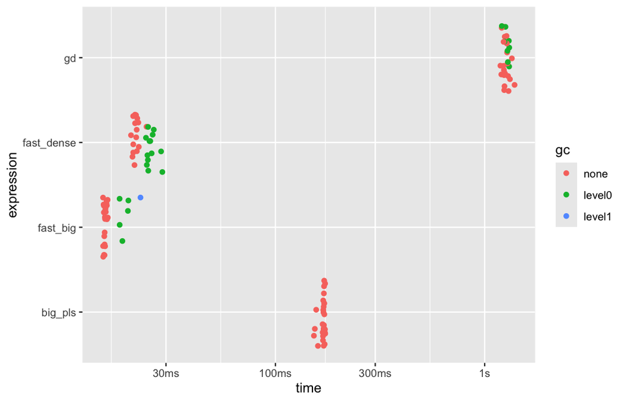

```r
if (exists("bench_res")) {
  plot(bench_res, type = "jitter")
}
```

# Cleaning up backing files

File-backed matrices can be deleted once the analysis is complete. In production workflows you typically keep the descriptor (`.desc`) file alongside the binary matrix for later reuse.

# Cleaning up

Temporary backing files can be removed after the analysis. In production pipelines you will typically keep the descriptor file alongside the binary data.

```r
if (exists("X_big")) {
  rm(X_big)
  file.remove(file.path(big_dir, "X.bin"))
  file.remove(file.path(big_dir, "X.desc"))
  unlink(big_dir, recursive = TRUE)
}
```

# Further resources

- The introductory vignette demonstrates how to combine the fast backend with the matrix-based modelling functions and deviance residual utilities.
- `vignette("bigPLScox-benchmarking", package = "bigPLScox")` provides a reproducible benchmark that includes `survival::coxph()` and `coxgpls()`.
- The help pages (`?big_pls_cox_fast`, `?big_pls_cox_gd`) describe all tuning parameters in detail, including `keepX` for component-wise sparsity.